# Stats199_Week8&9

Gabriel Fanucchi

11/22/2019

# Weeks 8-9: Statistical Inference with TDA

## Hypothesis Testing with Persistence

Suppose we have two point clouds, A and B. We can define a function T that returns the persistent homology of a point cloud, then given A and B, we can use a permutation test to perform statistical inference with the following null and alternative hypotheses:

$H_0:T(A) = T(B)$

$H_A:T(A) \ != T(B)$

We want to use this hypothesis test when we want to see if two point clouds are the same or not. For example, let’s compare the two point clouds unif3d and sphere3d:

The following code is sourced from [20], but the difference is we try this for unif3d and sphere3d rather than unif2d and circl2d which are used in [20]:

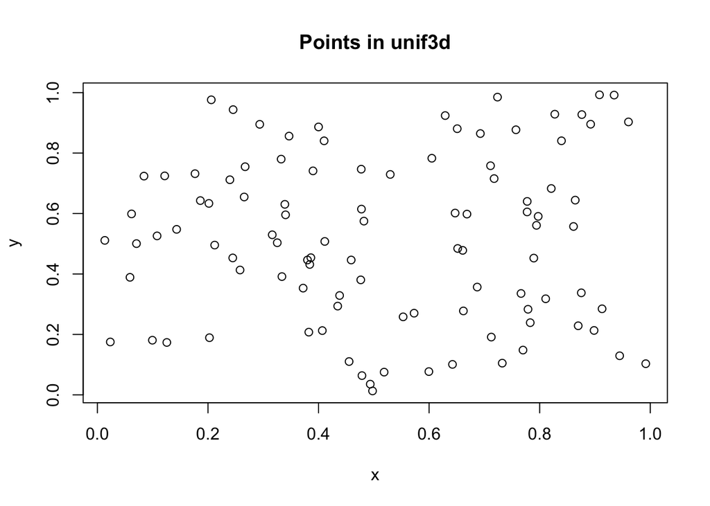

```r
# ensure reproducible results
set.seed(1)

# load TDAstats
library("TDAstats")

# load relevant datasets for case study
data("unif3d")
data("sphere3d")

# see if points in unif2d are actually distributed
# within a unit square as described above
plot(unif3d, xlab = "x", ylab = "y",
     main = "Points in unif3d")
```

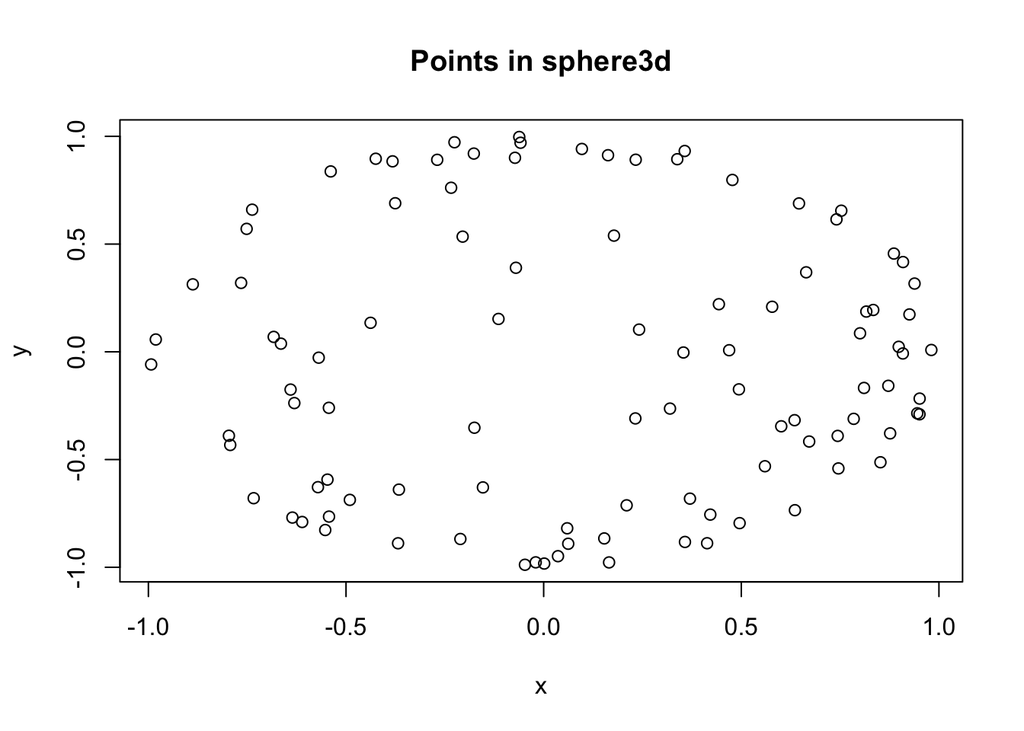

```r
# see if points in circle2d are actually distributed
# on the circumference of a unit circle as described
plot(sphere3d, xlab = "x", ylab = "y",
     main = "Points in sphere3d")
```

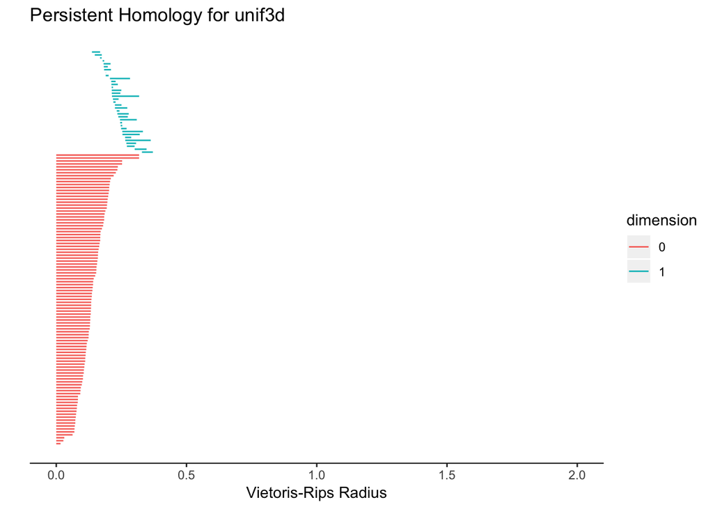

```r
library("ggplot2")
# calculate homologies for both datasets
unif.phom <- calculate_homology(unif3d, dim = 1)
circ.phom <- calculate_homology(sphere3d, dim = 1)


# plot barcodes with labels and identical axes
plot_barcode(unif.phom) +
  ggtitle("Persistent Homology for unif3d") +
  xlim(c(0, 2))
```

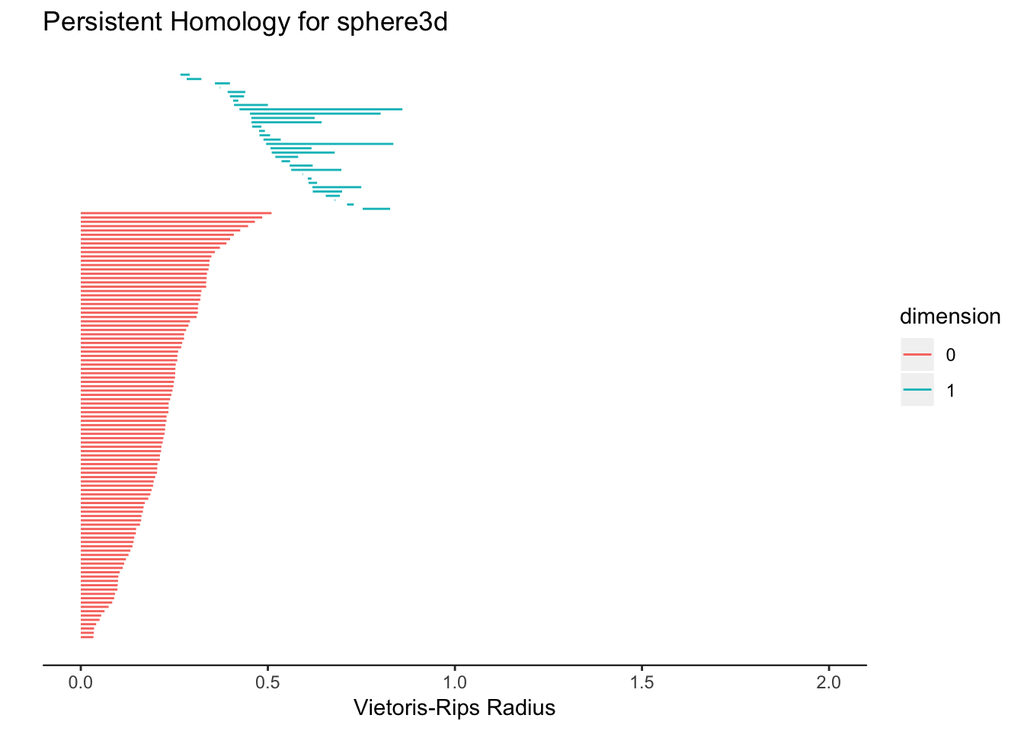

```r
plot_barcode(circ.phom) +
  ggtitle("Persistent Homology for sphere3d") +
  xlim(c(0, 2))
```

We can now run a permutation test on the two datasets to confirm that the persistent homologies of the two are, in fact, distinct. To do this, all we have to do is use the permutation_test function in TDAstats, and specify the number of iterations. Increasing the number of iterations improves how well the permutation test approximates the distribution of all point permutations between the two groups, but also comes at the cost of speed. Thus, a number of iterations that is sufficiently large to properly approximate the permutation distribution but not too large to be computed is required. Almost certainly, the ideal number of iterations will change as the available computing power changes. [20]

```r
# run permutation test
perm.test <- permutation_test(unif3d, sphere3d, iterations = 100)

# display p-value for 0-cycles
print(perm.test[[1]]$pvalue)
```

```
## [1] 0
```

```r
# display p-value for 1-cycles
print(perm.test[[2]]$pvalue)
```

```
## [1] 0
```

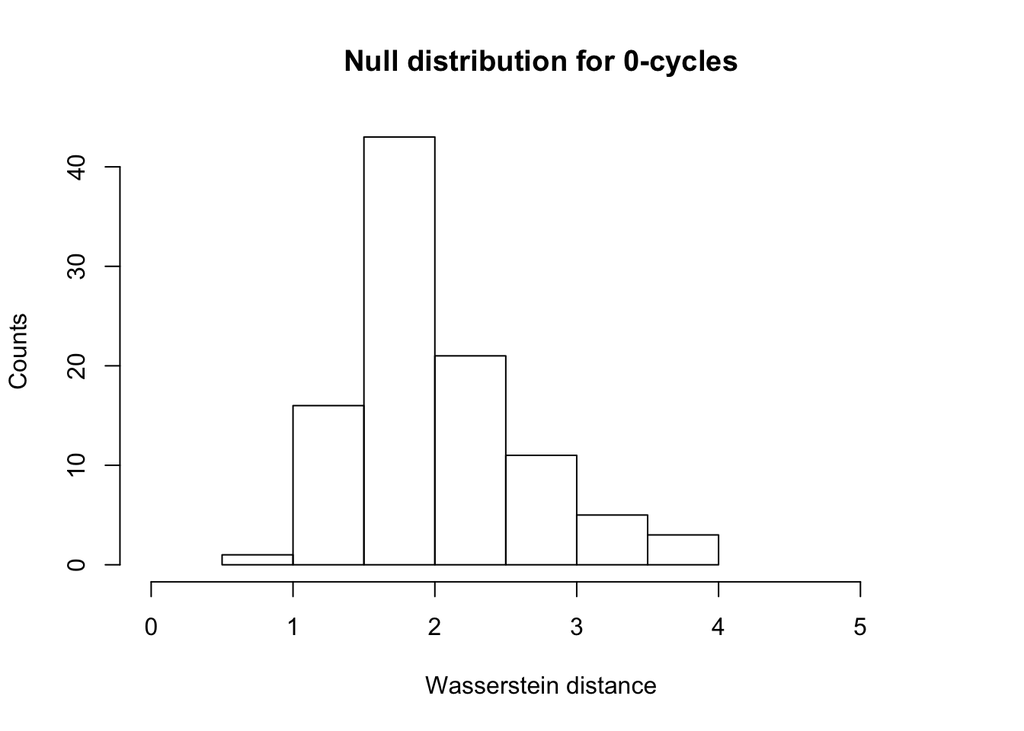

```r
# plot null distribution for 0-cycles as histogram
# and add vertical line at Wasserstein distance
# for original groups
hist(perm.test[[1]]$permvals,
     xlab = "Wasserstein distance",
     ylab = "Counts",
     main = "Null distribution for 0-cycles",
     xlim = c(0, 5.5))
abline(v = perm.test[[1]]$wasserstein)
```

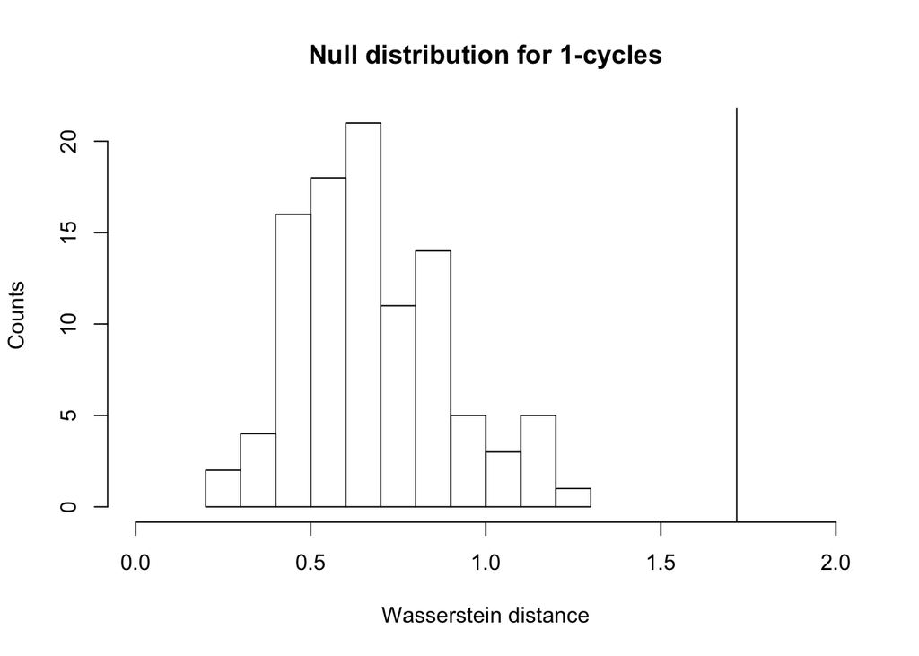

```r
# plot null distribution for 1-cycles as histogram
# and add vertical line at Wasserstein distance
# for original groups
hist(perm.test[[2]]$permvals,
     xlab = "Wasserstein distance",
     ylab = "Counts",
     main = "Null distribution for 1-cycles",
     xlim = c(0, 2))
abline(v = perm.test[[2]]$wasserstein)
```

## Persistence Landscapes

A persistence landscape is a useful tool when performing statistical inference with TDA. They are evaluated over a one-dimensional grid of points. This is indicated by tseq in the code below. If we set KK = 1, this means that we are looking for the 1st landscape function. [23]

$\textbf{Definition}$ (Persistence landscape): [21] A $\textit{persistence landscape}$ is a function $\lambda: \mathbb{N} \times \mathbb{R} \rightarrow [-\infty ,\infty]$ where $\lambda_k(x)$ = k-th largest value of $min(x-b_i,d_i-x)$

The following code block is sourced from [23]:

```r
require(TDA)
```

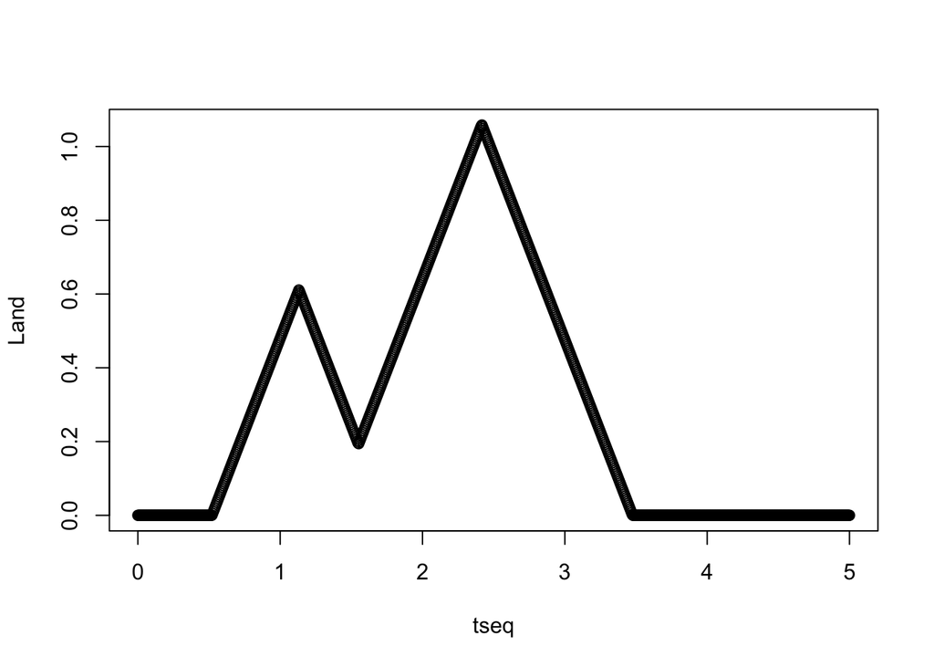

```r
maxscale <- 5
maxdimension <- 1
Circle1 <- circleUnif(60)
Circle2 <- circleUnif(60, r = 2) + 3
Circles <- rbind(Circle1, Circle2)

Diag <- ripsDiag(X = Circles,
                 maxdimension,
                 maxscale,
                 library = "GUDHI",
                 printProgress = FALSE)
tseq <- seq(0, maxscale, length = 1000)   #domain
Land <- landscape(Diag[["diagram"]], dimension = 1, KK = 1, tseq)
plot(tseq,Land)
```

This code block is sourced from [19]:

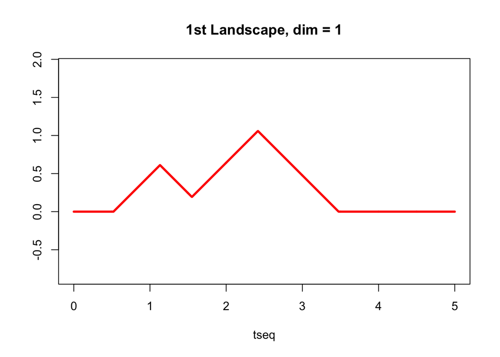

```r
tseq <- seq(from = 0, to = 5, length = 1000) #domain
Land <- landscape(Diag = Diag[["diagram"]], dimension = 1, KK = 1, tseq = tseq)
par(mfrow=c(1,1))
plot(tseq, Land, type = "l", main = "1st Landscape, dim = 1", ylab = "",
asp = 1, col = "red", lwd = 3)
```

This allows for a mean that is not in persistence diagrams. Another advantage of using persistence landscapes is that they also are invertible.[21]

Here is a useful visualization that shows how we get a persistence landscape from a persistence diagram: [22]

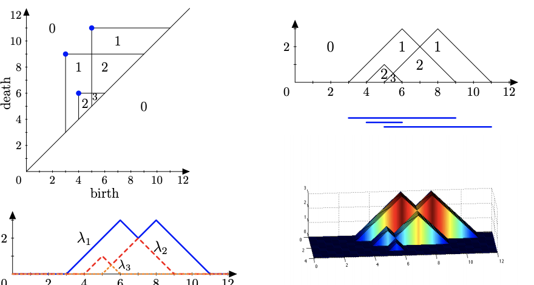

Persistence Landscape